# ExploratoryVis - Census

April 24, 2016

## Data Set

Using the resource, UCI Machine Learning Repository, found the Census-Income (KDD) Data Set. Consisted of nearly 300,000 observations of 40 different variables of weighted census data. Weighted, meaning that each combination of the 40 different variables was given a weight equivalent to the number of persons in the U.S. population with those attributes.

The Census data is from 1994 and 1995, and the following graphs are averaged between the two years.

Wanted to explore the different effects of race and gender on the representation of population with a full-time income greater than $50,000.

Required some cleaning and filtering to use only the full-time income census observations.

## Income by Sector

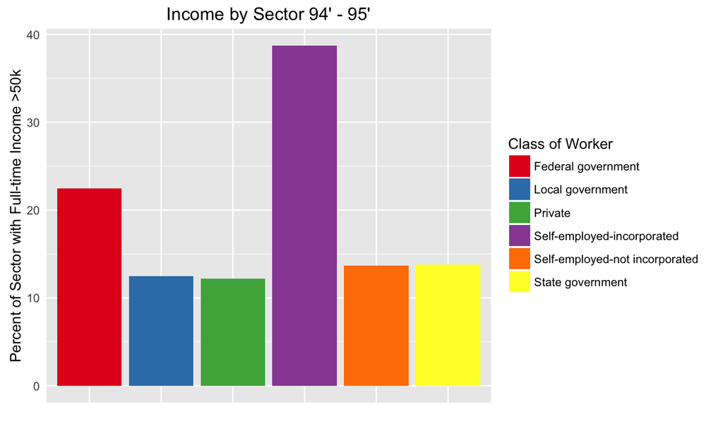

## Between Males and Females

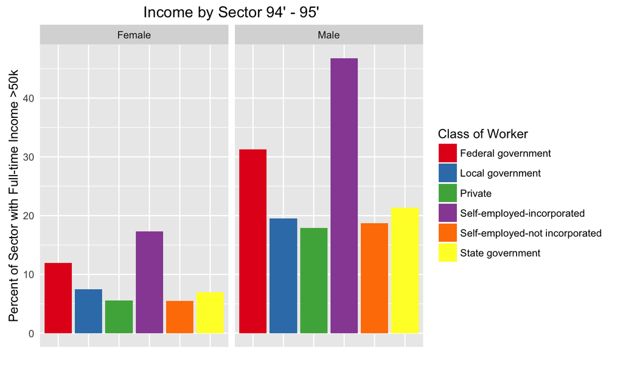

## Income Percentages Between Males and Females

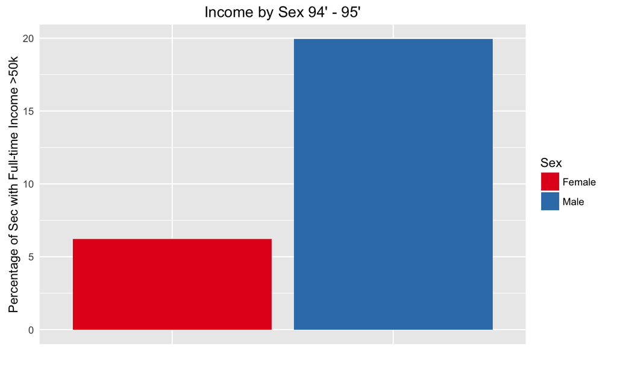

## Questions

-Why is there such a significant difference between males and females among those who make >50k?

-Do we see similar effects between races?

-Keep in mind that all graphs only include those with full-time jobs.

## Income by Race

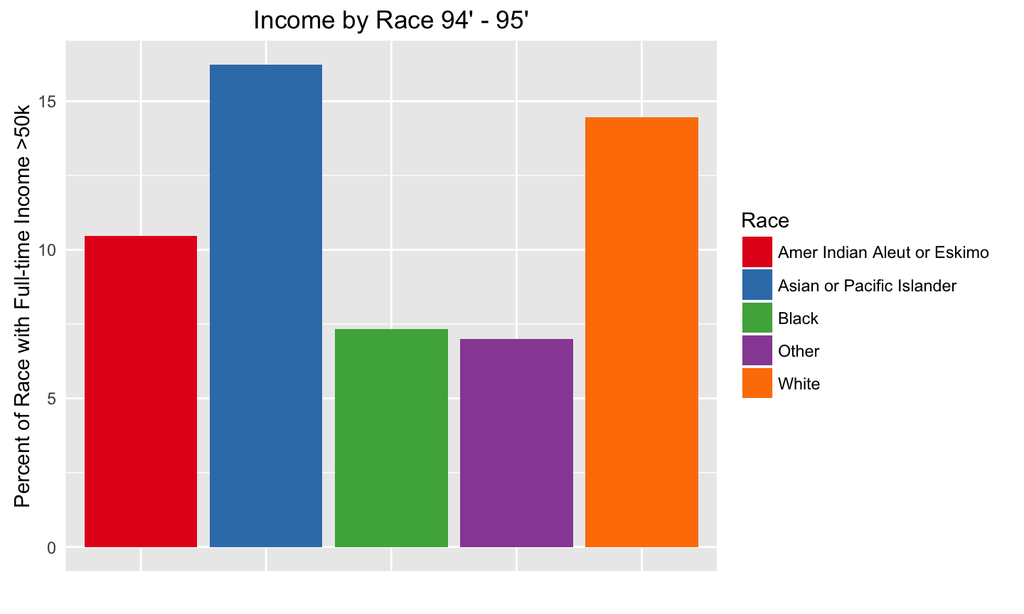

## Income by Race and Sex

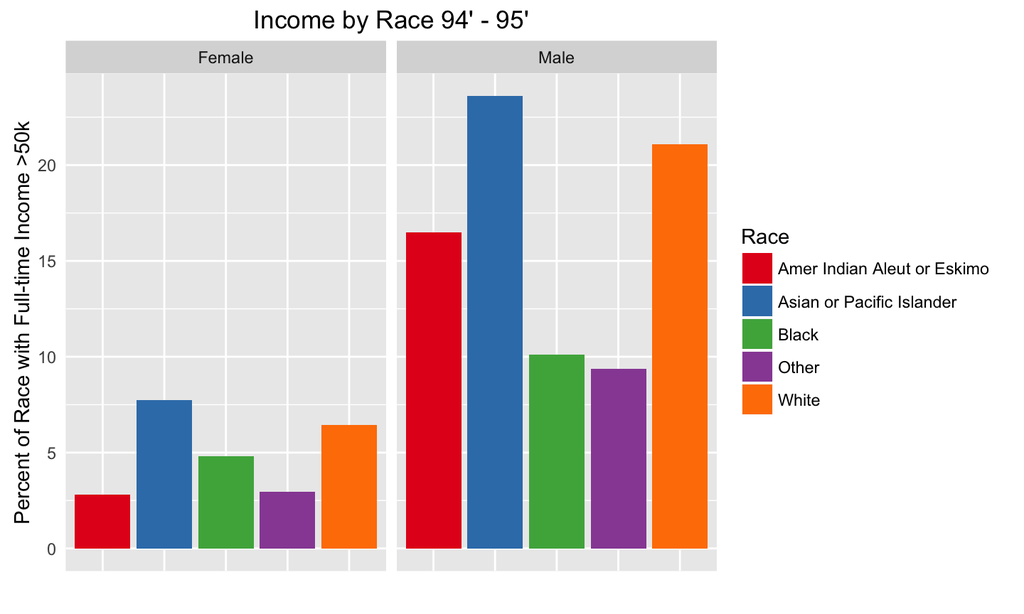

## Income by age

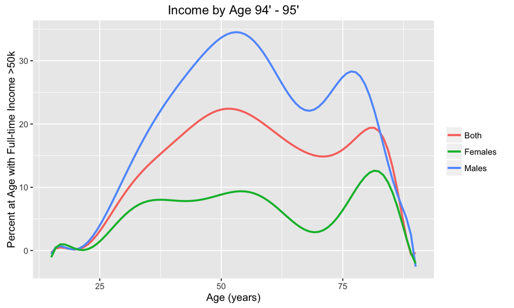

## More Questions

-Could there be a difference in education?

-Why is there a dip at ~70 years old?

## Population Education Stats

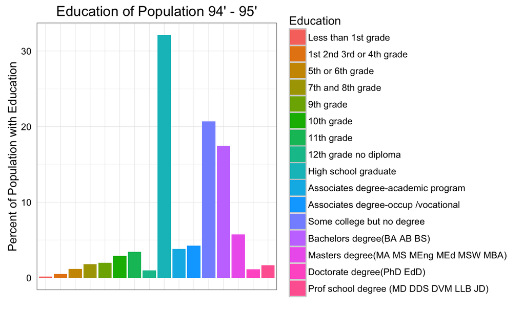

## Between Male and Female

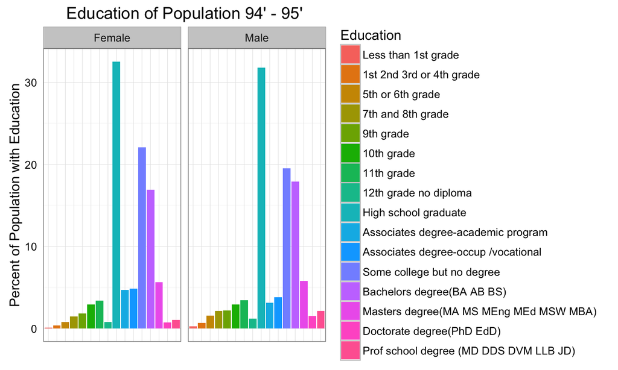

## Income by Education and Sex

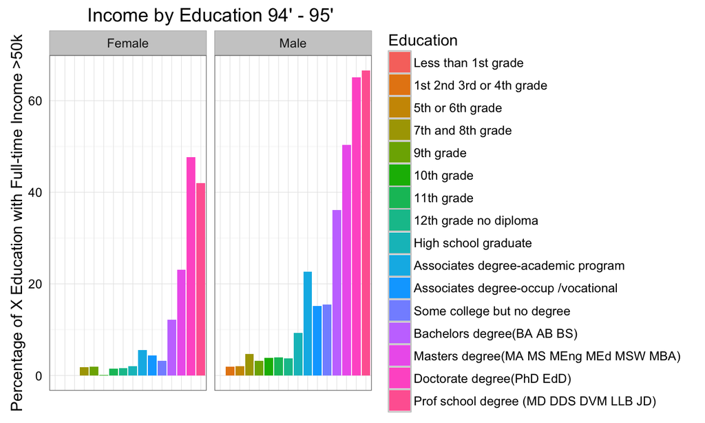